# Practica Final SVM Classification

Aprendizaje Estadístico II

Kelly Raas

06 June 2019

# 1 Introduction

This practice attempts to llustrate a classification approach using SVM and NN and compare the outcomes to other classification methods. The goal is predicting whether bank clients will subscribe (yes/no) a term deposit (target variable). It is a binary (2-class) classification problem.

# 2 Data

```r
# Loading data
data = read.csv("bank-full.csv", sep = ";")
head(data)
```

```
  age          job marital education default balance housing loan contact
1  58   management married  tertiary      no    2143     yes   no unknown
2  44   technician  single secondary      no      29     yes   no unknown
3  33 entrepreneur married secondary      no       2     yes  yes unknown
4  47  blue-collar married   unknown      no    1506     yes   no unknown
5  33      unknown  single   unknown      no       1      no   no unknown
6  35   management married  tertiary      no     231     yes   no unknown
  day month duration campaign pdays previous poutcome  y
1   5   may      261        1    -1        0  unknown no
2   5   may      151        1    -1        0  unknown no
3   5   may       76        1    -1        0  unknown no
4   5   may       92        1    -1        0  unknown no
5   5   may      198        1    -1        0  unknown no
6   5   may      139        1    -1        0  unknown no
```

The dataset consistes of 45.211 observations on customer data on direct marketing campaigns (phone calls) of a Portuguese banking institution, with following variables:

Bank Client data:

- age
- job
- marital
- education
- default status
- housing
- loan

Related with the last contact of the current campaign:

- last contact type
- last contact month of year
- last contact day of the week
- last contact duration

Others attributes:

- number of contacts performed in current campaign
- number of days that passed by after the client was last contacted
- number of contacts performed before this campaign, outcome of previous campaign
- whether a client has subscribed a term deposit (output variable)

## 2.1 Data Exploration

Let us first see the summary and general statistics of our data set.

```r
# General summary of all attributes
summary(data)
```

```
      age                 job           marital          education
 Min.   :18.00   blue-collar:9732   divorced: 5207   primary  : 6851
 1st Qu.:33.00   management :9458   married :27214   secondary:23202
 Median :39.00   technician :7597   single  :12790   tertiary :13301
 Mean   :40.94   admin.     :5171                    unknown  : 1857
 3rd Qu.:48.00   services   :4154
 Max.   :95.00   retired    :2264
                 (Other)    :6835
 default        balance       housing      loan            contact
 no :44396   Min.   : -8019   no :20081   no :37967   cellular :29285
 yes:  815   1st Qu.:    72   yes:25130   yes: 7244   telephone: 2906
             Median :   448                           unknown  :13020
             Mean   :  1362
             3rd Qu.:  1428
             Max.   :102127

      day            month          duration         campaign
 Min.   : 1.00   may    :13766   Min.   :   0.0   Min.   : 1.000
 1st Qu.: 8.00   jul    : 6895   1st Qu.: 103.0   1st Qu.: 1.000
 Median :16.00   aug    : 6247   Median : 180.0   Median : 2.000
 Mean   :15.81   jun    : 5341   Mean   : 258.2   Mean   : 2.764
 3rd Qu.:21.00   nov    : 3970   3rd Qu.: 319.0   3rd Qu.: 3.000
 Max.   :31.00   apr    : 2932   Max.   :4918.0   Max.   :63.000
                 (Other): 6060
     pdays          previous           poutcome       y
 Min.   : -1.0   Min.   :  0.0000   failure: 4901   no :39922
 1st Qu.: -1.0   1st Qu.:  0.0000   other  : 1840   yes: 5289
 Median : -1.0   Median :  0.0000   success: 1511
 Mean   : 40.2   Mean   :  0.5803   unknown:36959
 3rd Qu.: -1.0   3rd Qu.:  0.0000
 Max.   :871.0   Max.   :275.0000
```

```r
# Statistical summary of all attributes
str(data)
```

```
'data.frame':   45211 obs. of  17 variables:
 $ age      : int  58 44 33 47 33 35 28 42 58 43 ...
 $ job      : Factor w/ 12 levels "admin.","blue-collar",..: 5 10 3 2 12 5 5 3 6 10 ...
 $ marital  : Factor w/ 3 levels "divorced","married",..: 2 3 2 2 3 2 3 1 2 3 ...
 $ education: Factor w/ 4 levels "primary","secondary",..: 3 2 2 4 4 3 3 3 1 2 ...
 $ default  : Factor w/ 2 levels "no","yes": 1 1 1 1 1 1 1 2 1 1 ...
 $ balance  : int  2143 29 2 1506 1 231 447 2 121 593 ...
 $ housing  : Factor w/ 2 levels "no","yes": 2 2 2 2 1 2 2 2 2 2 ...
 $ loan     : Factor w/ 2 levels "no","yes": 1 1 2 1 1 1 2 1 1 1 ...
 $ contact  : Factor w/ 3 levels "cellular","telephone",..: 3 3 3 3 3 3 3 3 3 3 ...
 $ day      : int  5 5 5 5 5 5 5 5 5 5 ...
 $ month    : Factor w/ 12 levels "apr","aug","dec",..: 9 9 9 9 9 9 9 9 9 9 ...
 $ duration : int  261 151 76 92 198 139 217 380 50 55 ...
 $ campaign : int  1 1 1 1 1 1 1 1 1 1 ...
 $ pdays    : int  -1 -1 -1 -1 -1 -1 -1 -1 -1 -1 ...
 $ previous : int  0 0 0 0 0 0 0 0 0 0 ...
 $ poutcome : Factor w/ 4 levels "failure","other",..: 4 4 4 4 4 4 4 4 4 4 ...
 $ y        : Factor w/ 2 levels "no","yes": 1 1 1 1 1 1 1 1 1 1 ...
```

```r
# Summarize the levels of the class attribute
data_x <- data[,1:(ncol(data)-1)]
data_y <- data[,ncol(data)]
cbind(freq=table(data_y), percentage=prop.table(table(data_y))*100)
```

```
     freq percentage
no  39922   88.30152
yes  5289   11.69848
```

```r
# Count missing values
sapply(data, function(x) sum(is.na(x)))
```

```
      age       job   marital education   default   balance   housing
        0         0         0         0         0         0         0
     loan   contact       day     month  duration  campaign     pdays
        0         0         0         0         0         0         0
 previous  poutcome         y
        0         0         0
```

The data looks alright so far and we do not have to make any changes to the variable types. However, there are a few things we can already observe:

- There is no missing data (NA’s) which is good.
- There are some “unknown” data for the variables `education`, `contact` and `poutcome`.
- The outcome variable `y` is highly screwed and we will have to deal with this unbalance.
- There seems to be an outlier in the `previous` variable as 275 seems a very high number.

## 2.2 Data Visualization

Next, we will visualize the relationship between some variable versus our target variable.

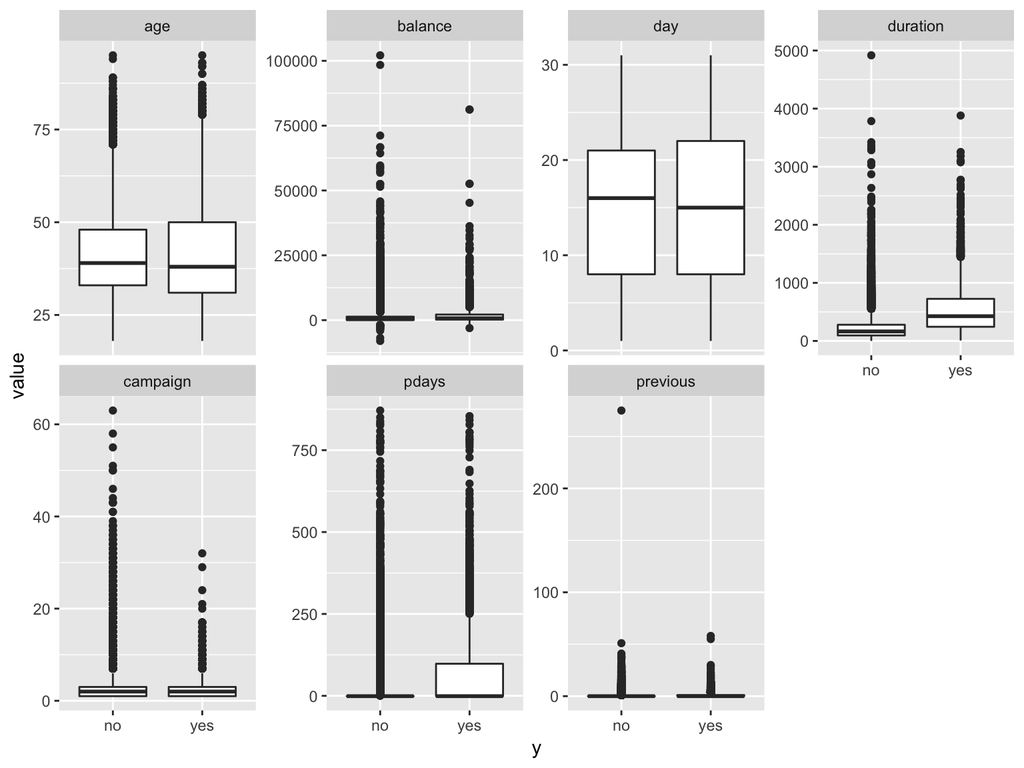

```r
ggplot(data = melt(data), mapping = aes(x = y, y = value)) +
    geom_boxplot() + facet_wrap(~variable, scales = 'free_y', ncol = 4)
```

From this visualization we can deduce that except from `duration` and perhaps `pdays` the other variables do not seem to have significant influence on the target variable. All variables present a lot of outliers. However these are all values that are explainable, exept from the outlier in the `previous` variable which is probably an erroneous datapoint.

Let’s also check the relationship of the categorical variables.

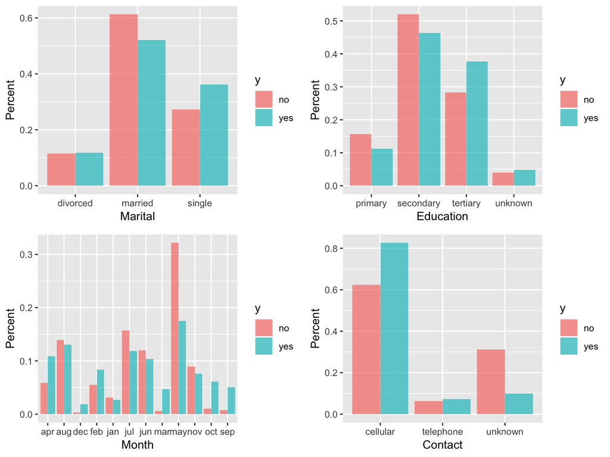

```r
# Prepae data
tab1 <- as.data.frame(prop.table(table(data$marital, data$y), 2))
colnames(tab1) <-  c("marital", "y", "perc")

tab2 <- as.data.frame(prop.table(table(data$education, data$y), 2))
colnames(tab2) <-  c("education", "y", "perc")

tab3 <- as.data.frame(prop.table(table(data$month, data$y), 2))
colnames(tab3) <-  c("month", "y", "perc")

tab4 <- as.data.frame(prop.table(table(data$contact, data$y), 2))
colnames(tab4) <-  c("contact", "y", "perc")


# Create plots
marital = ggplot(data = tab1, aes(x = marital, y = perc, fill = y)) +
  geom_bar(stat = 'identity', position = 'dodge', alpha = 2/3) +
  xlab("Marital")+
  ylab("Percent")

education = ggplot(data = tab2, aes(x = education, y = perc, fill = y)) +
  geom_bar(stat = 'identity', position = 'dodge', alpha = 2/3) +
  xlab("Education") +
  ylab("Percent")

month = ggplot(data = tab3, aes(x = month, y = perc, fill = y)) +
  geom_bar(stat = 'identity', position = 'dodge', alpha = 2/3) +
  xlab("Month")+
  ylab("Percent")

contact = ggplot(data = tab4, aes(x = contact, y = perc, fill = y)) +
  geom_bar(stat = 'identity', position = 'dodge', alpha = 2/3) +
  xlab("Contact")+
  ylab("Percent")


grid.arrange(marital, education, month, contact, nrow = 2)
```

## 2.3 Data Cleaning and Preparation

In order to prepare our dataset for modelling we will perform some modifications. First we will remove the outlier from the `previous` variable and also filtere out the observations where duration = 0, since this means that no call were made. Thus, it doesn’t make sense to have these observations in our analysis. Furthermore we will convert the target variable into a binary variable.

```r
data = data %>%
  filter(!previous > 150) %>%
  filter(duration != 0) %>%
  mutate(y = ifelse(y=="yes", 1, 0))
```

Next, we will create dummy variables for the categorical variables as this will be required for some algorithms.

```r
dummies = dummyVars(~ ., data = data)
df = data.frame(predict(dummies, newdata = data))
head(df)
```

```
  age job.admin. job.blue.collar job.entrepreneur job.housemaid
1  58          0               0                0             0
2  44          0               0                0             0
3  33          0               0                1             0
4  47          0               1                0             0
5  33          0               0                0             0
6  35          0               0                0             0
  job.management job.retired job.self.employed job.services job.student
1              1           0                 0            0           0
2              0           0                 0            0           0
3              0           0                 0            0           0
4              0           0                 0            0           0
5              0           0                 0            0           0
6              1           0                 0            0           0
  job.technician job.unemployed job.unknown marital.divorced
```

[output cut: 55 more lines]

We can drop one of the dummy variables for each categories as we only need n−1 dummy variables.

```r
names(df)
```

```
 [1] "age"                 "job.admin."          "job.blue.collar"
 [4] "job.entrepreneur"    "job.housemaid"       "job.management"
 [7] "job.retired"         "job.self.employed"   "job.services"
[10] "job.student"         "job.technician"      "job.unemployed"
[13] "job.unknown"         "marital.divorced"    "marital.married"
[16] "marital.single"      "education.primary"   "education.secondary"
[19] "education.tertiary"  "education.unknown"   "default.no"
[22] "default.yes"         "balance"             "housing.no"
[25] "housing.yes"         "loan.no"             "loan.yes"
[28] "contact.cellular"    "contact.telephone"   "contact.unknown"
[31] "day"                 "month.apr"           "month.aug"
[34] "month.dec"           "month.feb"           "month.jan"
[37] "month.jul"           "month.jun"           "month.mar"
[40] "month.may"           "month.nov"           "month.oct"
[43] "month.sep"           "duration"            "campaign"
[46] "pdays"               "previous"            "poutcome.failure"
[49] "poutcome.other"      "poutcome.success"    "poutcome.unknown"
[52] "y"
```

```r
df = dplyr::select(df, -c("job.unknown","education.unknown","marital.divorced","education.unknown","default.no","housing.no","loan.no","contact.unknown","month.jan"))
```

Lastly, since the variables are of different magnitude, scaling is recommended. We will use the min-max method and scale the data in the interval [0,1].

```r
dfsc = as.data.frame(apply(df, 2, function(x){(x-min(x))/(max(x)-min(x))}))
summary(dfsc)
```

```
      age           job.admin.     job.blue.collar  job.entrepreneur
 Min.   :0.0000   Min.   :0.0000   Min.   :0.0000   Min.   :0.00000
 1st Qu.:0.1948   1st Qu.:0.0000   1st Qu.:0.0000   1st Qu.:0.00000
 Median :0.2727   Median :0.0000   Median :0.0000   Median :0.00000
 Mean   :0.2979   Mean   :0.1144   Mean   :0.2153   Mean   :0.03287
 3rd Qu.:0.3896   3rd Qu.:0.0000   3rd Qu.:0.0000   3rd Qu.:0.00000
 Max.   :1.0000   Max.   :1.0000   Max.   :1.0000   Max.   :1.00000
 job.housemaid     job.management    job.retired      job.self.employed
 Min.   :0.00000   Min.   :0.0000   Min.   :0.00000   Min.   :0.00000
 1st Qu.:0.00000   1st Qu.:0.0000   1st Qu.:0.00000   1st Qu.:0.00000
 Median :0.00000   Median :0.0000   Median :0.00000   Median :0.00000
 Mean   :0.02743   Mean   :0.2092   Mean   :0.05008   Mean   :0.03493
 3rd Qu.:0.00000   3rd Qu.:0.0000   3rd Qu.:0.00000   3rd Qu.:0.00000
 Max.   :1.00000   Max.   :1.0000   Max.   :1.00000   Max.   :1.00000
  job.services      job.student      job.technician  job.unemployed
 Min.   :0.00000   Min.   :0.00000   Min.   :0.000   Min.   :0.00000
 1st Qu.:0.00000   1st Qu.:0.00000   1st Qu.:0.000   1st Qu.:0.00000
 Median :0.00000   Median :0.00000   Median :0.000   Median :0.00000
 Mean   :0.09189   Mean   :0.02075   Mean   :0.168   Mean   :0.02882
 3rd Qu.:0.00000   3rd Qu.:0.00000   3rd Qu.:0.000   3rd Qu.:0.00000
 Max.   :1.00000   Max.   :1.00000   Max.   :1.000   Max.   :1.00000
 marital.married  marital.single   education.primary education.secondary
 Min.   :0.0000   Min.   :0.0000   Min.   :0.0000    Min.   :0.0000
 1st Qu.:0.0000   1st Qu.:0.0000   1st Qu.:0.0000    1st Qu.:0.0000
 Median :1.0000   Median :0.0000   Median :0.0000    Median :1.0000
 Mean   :0.6019   Mean   :0.2829   Mean   :0.1515    Mean   :0.5132
 3rd Qu.:1.0000   3rd Qu.:1.0000   3rd Qu.:0.0000    3rd Qu.:1.0000
 Max.   :1.0000   Max.   :1.0000   Max.   :1.0000    Max.   :1.0000
 education.tertiary  default.yes         balance         housing.yes
 Min.   :0.0000     Min.   :0.00000   Min.   :0.00000   Min.   :0.0000
 1st Qu.:0.0000     1st Qu.:0.00000   1st Qu.:0.07346   1st Qu.:0.0000
 Median :0.0000     Median :0.00000   Median :0.07687   Median :1.0000
 Mean   :0.2942     Mean   :0.01803   Mean   :0.08517   Mean   :0.5558
 3rd Qu.:1.0000     3rd Qu.:0.00000   3rd Qu.:0.08577   3rd Qu.:1.0000
 Max.   :1.0000     Max.   :1.00000   Max.   :1.00000   Max.   :1.0000
    loan.yes      contact.cellular contact.telephone      day
 Min.   :0.0000   Min.   :0.0000   Min.   :0.00000   Min.   :0.0000
 1st Qu.:0.0000   1st Qu.:0.0000   1st Qu.:0.00000   1st Qu.:0.2333
 Median :0.0000   Median :1.0000   Median :0.00000   Median :0.5000
 Mean   :0.1602   Mean   :0.6477   Mean   :0.06428   Mean   :0.4935
```

[output cut: 22 more lines]

```
 Max.   :1.00000   Max.   :1.00000   Max.   :1.00000   Max.   :1.00000
    campaign           pdays            previous        poutcome.failure
 Min.   :0.00000   Min.   :0.00000   Min.   :0.000000   Min.   :0.0000
 1st Qu.:0.00000   1st Qu.:0.00000   1st Qu.:0.000000   1st Qu.:0.0000
 Median :0.01613   Median :0.00000   Median :0.000000   Median :0.0000
 Mean   :0.02844   Mean   :0.04724   Mean   :0.009902   Mean   :0.1084
 3rd Qu.:0.03226   3rd Qu.:0.00000   3rd Qu.:0.000000   3rd Qu.:0.0000
 Max.   :1.00000   Max.   :1.00000   Max.   :1.000000   Max.   :1.0000
 poutcome.other    poutcome.success  poutcome.unknown       y
 Min.   :0.00000   Min.   :0.00000   Min.   :0.0000   Min.   :0.000
 1st Qu.:0.00000   1st Qu.:0.00000   1st Qu.:1.0000   1st Qu.:0.000
 Median :0.00000   Median :0.00000   Median :1.0000   Median :0.000
 Mean   :0.04068   Mean   :0.03342   Mean   :0.8175   Mean   :0.117
 3rd Qu.:0.00000   3rd Qu.:0.00000   3rd Qu.:1.0000   3rd Qu.:0.000
 Max.   :1.00000   Max.   :1.00000   Max.   :1.0000   Max.   :1.000
```

## 2.4 Correlation Matrix

The correlation matrix will show us if there are any highly correlated variables. If independent variables are highly correlated, it can lead to problems of multicolinearity.

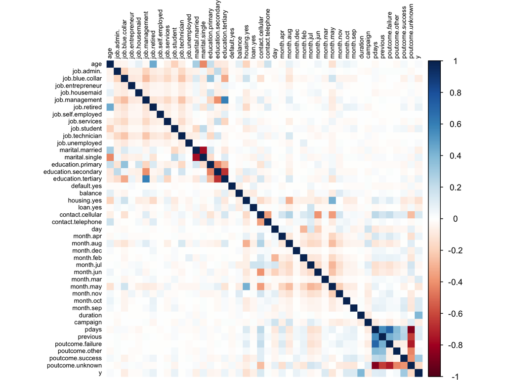

```r
corrplot(cor(dfsc), method = "color", tl.col="black", tl.cex = 0.6)
```

So from this matrix we see that in general there is not much correlation between the variables, appart from the few obvious between job type and education level. As well as between the outcome dummy variables.

## 2.5 Create Training and Test Set

In order to be able to test our models we will split our dataset into a training and a test set.

```r
set.seed(1991)
# Split subset into training and testset
index <- sample(1:nrow(dfsc), round(0.70*nrow(dfsc)))
train <- dfsc[index,]
test <- dfsc[-index,]
```

As we have seen above we have a highly imbalanced dataset with regard to our target variable. In order to get reliable accuracy scores we schould balence our data. We will use the SMOTE technique that synthecially generates new training examples. It is important to note that we will only enrich the training set with synthetic examples, not the test set.

```r
set.seed(1991)
train_smote = ubSMOTE(X = train[,names(train) != "y"],
                      Y = as.factor(train[,"y"]),
                      perc.over = 300,
                      k = 5,
                      perc.under = 200,
                      verbose = FALSE
                      )
train_smote = cbind(train_smote$X, y = as.numeric(levels(train_smote$Y))[train_smote$Y])
table(train_smote$y) / length(train_smote$y)
```

```
  0   1
0.6 0.4
```

As we can see we improved the balance of the target variable fom 90/10 to 60/40.

Due to limited processing power we will further reduce our trainingset to 5000 observations.

```r
set.seed(1)
# Create subset of the trainset
smalltrain = sample_n(train_smote, size = 5000, replace = F)
table(smalltrain$y)
```

```
   0    1
2978 2022
```

## 2.6 Set up the classificaton formula

For convenience we set up the classification formula.

```r
n = names(train)
f = as.formula(paste("y ~", paste(n[n != "y"], collapse = " + ")))
f
```

```
y ~ age + job.admin. + job.blue.collar + job.entrepreneur + job.housemaid +
    job.management + job.retired + job.self.employed + job.services +
    job.student + job.technician + job.unemployed + marital.married +
    marital.single + education.primary + education.secondary +
    education.tertiary + default.yes + balance + housing.yes +
    loan.yes + contact.cellular + contact.telephone + day + month.apr +
    month.aug + month.dec + month.feb + month.jul + month.jun +
    month.mar + month.may + month.nov + month.oct + month.sep +
    duration + campaign + pdays + previous + poutcome.failure +
    poutcome.other + poutcome.success + poutcome.unknown
```

## 2.7 Evaluation metrics

We will evaluate our models using following metrics:

- Accuracy: How often did we make a correct prediction? (TP + TN) / Total
- Precision: How many selected items are relevant? In this case: Out of all the times we predicted that a customer will subscribe, how often did they actually subscribe? TP / (TP + FP)
- Recall: How many relevant items are selected? In this case: Out of all the subscribtions, how often did we predict them? TP / (TP + FN)

```r
metrics = function(x, y){
  cm = confusionMatrix(as.factor(x), as.factor(y), positive = "1", mode = "prec_recall")
  prec = cm$byClass["Precision"]
  rec = cm$byClass["Recall"]
  acc = cm$overall["Accuracy"]
  df = data.frame(Accuracy = acc, Precision = prec, Recall = rec)
  row.names(df) = ""
  return(df)
}
```

Finally, we are done with the data preparation for model training.

# 3 Support Vector Machine (SVM) classification model

## 3.1 Parameter Tuning

SVM is very sensitive to the choice of parameters. Even close parameters values might lead to very different classification results. In order to find the best fit, we want to test some different values.

The two most important parameters for SVM are:

- C (cost): is responsible for the size of the “soft margin” of SVM. This means that points inside this soft margin are not classified as any of the two categories. The smaller the value of C, the greater the soft margin.
- γ (gama): is responsible for the linearity degree of the hyperplane. The smaller γ is, the more the hyperplane is going to look like a straight line. However, if γ is too big, the hyperplane will be more curvy and might lead to overfitting.

We will go with the default gamma and want to find the optimal cost parameter. Using the tune.svm() method we can test several different values, and return the ones which minimizes the classification error for the 10-fold cross validation.

```r
set.seed(1991)
# convert dependent variable into factor
smalltrain$y = as.factor(smalltrain$y)
levels(smalltrain$y)[smalltrain$y]
```

[output not shown]

[output cut: 280 more lines]

```r
# tune svm
svm_tuned = tune.svm(f,
                       data = smalltrain,
                       kernel = "linear" ,
                       type = "C-classification",
                       cost = 10^(-3:2))

summary(svm_tuned)
```

```
Parameter tuning of 'svm':

- sampling method: 10-fold cross validation

- best parameters:
 cost
  100

- best performance: 0.1542

- Detailed performance results:
     cost  error dispersion
1   0.001 0.1842 0.02007652
2   0.010 0.1596 0.01253617
3   0.100 0.1554 0.01326817
4   1.000 0.1548 0.01258571
5  10.000 0.1548 0.01276105
6 100.000 0.1542 0.01255919
```

The best results is obtained with C = 100 leading to missclassification error of 0.1542, which would mean an Accuracy of about 85%. The large value of C means that in this case a smaller-margin hyperplane with less missclassified points is prefered.

We have to keep in mind that the above result is on the training data, we now want to see how good our optimized model performs on our test data.

```r
linear_svm = svm_tuned$best.model
linear_svm.pred = predict(linear_svm, newdata = test)
# confusion matrix
table(linear_svm.pred, test$y)
```

```
linear_svm.pred     0     1
              0 10458   382
              1  1543  1179
```

```r
metrics(linear_svm.pred, test$y)
```

```
  Accuracy Precision    Recall
 0.8580593 0.4331374 0.7552851
```

Very nice, on the test set the model results in an Accuracy of nearly 86%. However, the precision value is quite low.

SVM is also very sensitive to the choice of the kernel so next we want to see if we get an improved model by using a radial kernel.

```r
set.seed(1991)
svm_tuned_rbf = tune.svm(f,
                       data = smalltrain,
                       kernel = "radial" ,
                       type = "C-classification",
                       cost = 10^(-3:2))

summary(svm_tuned_rbf)
```

```
Parameter tuning of 'svm':

- sampling method: 10-fold cross validation

- best parameters:
 cost
   10

- best performance: 0.1264

- Detailed performance results:
     cost  error dispersion
1   0.001 0.4044 0.02303234
2   0.010 0.4038 0.02319866
3   0.100 0.1698 0.01262977
4   1.000 0.1270 0.01317405
5  10.000 0.1264 0.02163947
6 100.000 0.1328 0.01776889
```

Indeed we seem to get a better result with the RBF kernel and C = 10 leading to missclassification error of 0.1264, or Accuracy of about 88%.

Again we need to test our model on the test data.

```r
rbf_svm = svm_tuned_rbf$best.model
rbf_svm.pred = predict(rbf_svm, newdata = test)
# confusion matrix
table(rbf_svm.pred, test$y)
```

```
rbf_svm.pred     0     1
           0 10563   468
           1  1438  1093
```

```r
metrics(rbf_svm.pred, test$y)
```

```
  Accuracy Precision    Recall
 0.8594603 0.4318451 0.7001922
```

We can see that on the test data the model does not perform significantly better than the previous model. Hence, this model might have slightly overfitted on the training set.

# 4 Artificial Neural Network comparative

We will start with a simple structure of with 10 hidden nodes.

## 4.1 One hidden layer

```r
# Convert dependent variable to numeric
smalltrain$y = as.numeric(as.character(smalltrain$y))
```

```r
set.seed(1991)
nn1 = neuralnet(formula = f,
                data = smalltrain,
                hidden = 10,
                linear.output = F,
                threshold = 0.01)
```

```r
# Compute outputs for test data
nn1.output = compute(nn1, test)$net.result
nn1.pred = round(nn1.output[,1])

# confusion matrix
table(nn1.pred, test$y)
```

```
nn1.pred     0     1
       0 10268   426
       1  1733  1135
```

```r
metrics(nn1.pred, test$y)
```

```
  Accuracy Precision   Recall
 0.8408052 0.3957462 0.727098
```

This model does not perform better than our SVM. Let’s try a net structure with multiple hidden layers.

## 4.2 Multiple hidden layers

```r
set.seed(1991)
nn2 = neuralnet(formula = f,
                data = smalltrain,
                hidden = c(5,3,2),
                linear.output = F,
                threshold = 0.1)
```

```r
# Compute outputs for test data
nn2.output = compute(nn2, test)$net.result
nn2.pred = round(nn2.output[,1])

# confusion matrix
table(as.numeric(nn2.pred), test$y)
```

```
        0     1
  0 10078   352
  1  1923  1209
```

```r
metrics(nn2.pred, test$y)
```

```
  Accuracy Precision    Recall
 0.8322519 0.3860153 0.7745035
```

It seems that the multiple layers did not improve the previous outcome.

## 4.3 ANN vs. SVM

```r
ev_svm1 = metrics(linear_svm.pred, test$y)
ev_svm2 = metrics(rbf_svm.pred, test$y)
ev_nn1 = metrics(nn1.pred, test$y)
ev_nn2 = metrics(nn2.pred, test$y)

evaluation = rbind(ev_svm1,ev_svm2,ev_nn1,ev_nn2)
rownames(evaluation) = c("Linear SVM",
                      "RBF SVM",
                      "ANN 1",
                      "ANN 2")
evaluation
```

```
            Accuracy Precision    Recall
Linear SVM 0.8580593 0.4331374 0.7552851
RBF SVM    0.8594603 0.4318451 0.7001922
ANN 1      0.8408052 0.3957462 0.7270980
ANN 2      0.8322519 0.3860153 0.7745035
```

Our ANN models did not perform better than our SVM models. However, we should consider that there is no blueprint to fitting a neural network and small changes can lead to very different results. Maybe a different setting could still lead to better results.

# 5 More comparative Models

To compare the results obtained with the SVM and ANN we will further evaluate following algorithms:

- Logistic Regression
- k-Nearest Neighbors
- Decision Tree
- Random Forest
- Linear Discriminant Analysis

## 5.1 Logistic Regression

```r
set.seed(1991)
# convert dependent variable into factor
smalltrain$y = as.factor(smalltrain$y)

# Logistic Regression (Classification)
glm = glm(formula = f, data = smalltrain, family = binomial('logit'))
summary(glm)
```

```
Call:
glm(formula = f, family = binomial("logit"), data = smalltrain)

Deviance Residuals:
    Min       1Q   Median       3Q      Max
-6.0914  -0.5232  -0.2142   0.5045   3.0230

Coefficients: (1 not defined because of singularities)
                     Estimate Std. Error z value             Pr(>|z|)
(Intercept)         -4.822778   0.653624  -7.379     0.00000000000016 ***
age                  0.185153   0.399952   0.463             0.643408
job.admin.          -0.108983   0.519420  -0.210             0.833811
job.blue.collar     -0.411844   0.519144  -0.793             0.427595
job.entrepreneur     0.125315   0.561754   0.223             0.823474
job.housemaid       -0.627813   0.578021  -1.086             0.277416
job.management      -0.070641   0.516978  -0.137             0.891313
job.retired          0.452855   0.534512   0.847             0.396866
job.self.employed   -0.721856   0.557564  -1.295             0.195438
job.services        -0.088171   0.528833  -0.167             0.867584
job.student          0.878430   0.556241   1.579             0.114284
job.technician      -0.275447   0.516514  -0.533             0.593840
job.unemployed      -0.252654   0.558099  -0.453             0.650761
marital.married      0.004488   0.147440   0.030             0.975719
marital.single       0.302156   0.165468   1.826             0.067839 .
education.primary   -0.122759   0.257564  -0.477             0.633637
education.secondary  0.438032   0.229018   1.913             0.055792 .
education.tertiary   0.724404   0.240239   3.015             0.002567 **
default.yes          0.077804   0.422422   0.184             0.853868
balance              0.600767   1.459173   0.412             0.680547
housing.yes         -0.996080   0.103339  -9.639 < 0.0000000000000002 ***
loan.yes            -0.727063   0.145335  -5.003     0.00000056544681 ***
contact.cellular     1.699224   0.163928  10.366 < 0.0000000000000002 ***
contact.telephone    1.415041   0.237464   5.959     0.00000000253826 ***
day                 -0.019662   0.177310  -0.111             0.911703
month.apr            0.961470   0.272775   3.525             0.000424 ***
month.aug            0.252922   0.269181   0.940             0.347425
month.dec            1.732308   0.541272   3.200             0.001372 **
month.feb            0.796543   0.296506   2.686             0.007222 **
month.jul            0.295019   0.268473   1.099             0.271820
month.jun            1.432798   0.301313   4.755     0.00000198266884 ***
```

[output cut: 8 more lines]

```
previous             4.383822   1.418652   3.090             0.002001 **
poutcome.failure     0.020463   0.239279   0.086             0.931847
poutcome.other       0.430202   0.288593   1.491             0.136043
poutcome.success     2.840187   0.264749  10.728 < 0.0000000000000002 ***
poutcome.unknown           NA         NA      NA                   NA
---
Signif. codes:  0 '***' 0.001 '**' 0.01 '*' 0.05 '.' 0.1 ' ' 1

(Dispersion parameter for binomial family taken to be 1)

    Null deviance: 6747.6  on 4999  degrees of freedom
Residual deviance: 3666.5  on 4957  degrees of freedom
AIC: 3752.5

Number of Fisher Scoring iterations: 6
```

```r
glm.pred = predict(glm, test, type = "response")
glm.pred = ifelse(glm.pred >= 0.5, 1, 0)
# confusion matrix
table(glm.pred, test$y)
```

```
glm.pred     0     1
       0 10587   416
       1  1414  1145
```

```r
metrics(glm.pred, test$y)
```

```
  Accuracy Precision    Recall
 0.8650641 0.4474404 0.7335042
```

The logistic regression performs slightly better than our SVM. We can also see that none of the job variables seem to be statistically relevant for the model. On the other side the variables on housing, loan, month, and duration for example do show statistical significance.

## 5.2 K-Nearest Neighbours

```r
knn1 = class::knn(smalltrain, test, cl = smalltrain$y, k = 5)
# confusion matrix
table(knn1, test$y)
```

```
knn1     0     1
   0 11675   103
   1   326  1458
```

```r
metrics(knn1, test$y)
```

```
  Accuracy Precision    Recall
 0.9683675 0.8172646 0.9340167
```

This model is by far the best by now with an Accuracy of around 96%, as well as showing very high precision and recall values.

## 5.3 Decision Tree Model

```r
library(rpart)
tree = rpart(f, data=smalltrain, method="class", minbucket=20)
tree.pred = predict(tree, test, type = "class")
# confusion matrix
table(tree.pred, test$y)
```

```
tree.pred     0     1
        0 10291   474
        1  1710  1087
```

```r
metrics(tree.pred, test$y)
```

```
  Accuracy Precision    Recall
 0.8389618 0.3886307 0.6963485
```

This model does not perform any better than our previous models.

## 5.4 Random Forest Model

```r
library(randomForest)
rf <- randomForest(f, data = smalltrain, ntree = 1000)
rf.pred <- predict(rf, newdata = test, type = 'class')
# confusion matrix
table(rf.pred, test$y)
```

```
rf.pred     0     1
      0 10794   440
      1  1207  1121
```

```r
metrics(rf.pred, test$y)
```

```
  Accuracy Precision    Recall
 0.8785577 0.4815292 0.7181294
```

This model is slightly better than the logistic regression.

## 5.5 Linear Discriminant Analysis

```r
library(MASS)
lda1 = lda(f, smalltrain ,family=binomial)
lda.pred = predict(lda1, test)$class
# confusion matrix
table(lda.pred, test$y)
```

```
lda.pred     0     1
       0 10824   479
       1  1177  1082
```

```r
metrics(lda.pred, test$y)
```

```
  Accuracy Precision    Recall
 0.8778941  0.478973 0.6931454
```

This model gets also quite similar results to the previous model.

## 5.6 Comparison

Let’s now get a final overview of all the models and compare it to our SVM model.

```r
ev_glm = metrics(glm.pred, test$y)
ev_knn = metrics(knn1, test$y)
ev_tree = metrics(tree.pred, test$y)
ev_rf = metrics(rf.pred, test$y)
ev_lda = metrics(lda.pred, test$y)

evaluation = rbind(ev_svm1, ev_glm,ev_knn,ev_tree,ev_rf, ev_lda)
rownames(evaluation) = c("Linear SVM",
                      "Logistic Regression",
                      "k-Nearest Neighbors",
                      "Decision Tree",
                      "Random Forest",
                      "Linear Discriminant Analysis")
evaluation
```

```
                              Accuracy Precision    Recall
Linear SVM                   0.8580593 0.4331374 0.7552851
Logistic Regression          0.8650641 0.4474404 0.7335042
k-Nearest Neighbors          0.9683675 0.8172646 0.9340167
Decision Tree                0.8389618 0.3886307 0.6963485
Random Forest                0.8785577 0.4815292 0.7181294
Linear Discriminant Analysis 0.8778941 0.4789730 0.6931454
```

# 6 Final Conclusion

Over all models performed similar in terms of Accuracy, Precision and Recall. However, our kNN model clearly differs from the generall result, being the best model by far. Thus, for this particular classification problem, the KNN model would be the right choice.

One of the major factor that could influence the obtained results is the size of our training set. Due to limited processing power only a subset of the training set was used. Therefore, we might see improvements for some models if trained on a larger dataset. Also, with regard to the SVM other kernels could be tried as well as tuning the gamma parameter in order to improve the results.